# CARPS Reproducibility Report

# Report Details

```r
articleID <- "CARPS_8-12-2014-PS" # insert the article ID code here e.g., "10-3-2015_PS"
reportType <- 'pilot' # specify whether this is the 'pilot' report or 'final' report
pilotNames <- 'Bria Long' # insert the pilot's name here e.g., "Tom Hardwicke".  If there are multiple cpilots enter both names in a character string e.g., "Tom Hardwicke, Bob Dylan"
copilotNames <- NA # # insert the co-pilot's name here e.g., "Michael Frank". If there are multiple co-pilots enter both names in a character string e.g., "Tom Hardwicke, Bob Dylan"
pilotTTC <- 180 # insert the pilot's estimated time to complete (in minutes, fine to approximate) e.g., 120
copilotTTC <- NA # insert the co-pilot's estimated time to complete (in minutes, fine to approximate) e.g., 120
pilotStartDate <- 10/19/2018 # insert the pilot's start date in US format e.g., as.Date("01/25/18", format = "%m/%d/%y")
copilotStartDate <- NA # insert the co-pilot's start date in US format e.g., as.Date("01/25/18", format = "%m/%d/%y")
completionDate <- NA # copilot insert the date of final report completion (after any necessary rounds of author assistance) in US format e.g., as.Date("01/25/18", format = "%m/%d/%y")
```

#### Methods summary:

The authors calculated the d’1 and d’2 for a grammatical judgement experiment in which participants gave both a response and made a confidence judgement about this response. These d’1 and d’2 values are compared in subjects who showed a d’1 performance below zero in the first 75% of trials vs. subjects who did not.

#### Target outcomes:

Figure 3 illustrates the mean d′1 and d′2 for the analysis trials (final 25%); results are plotted separately for participants who performed above chance in the selection trials (first 75%) and those who performed at or below chance in the selection trials. Analyses were conducted listwise to ensure that the means for each index were based on the same participants. Among participants who exhibited first-order accuracy in the selection trials, d′2 was significantly greater than chance, t(164) = 4.65, p < .001, d = 0.36, and showed the typical relationship with d′1, specifically that the mean of d′2 is approximately half that of d′1 (Krueger, Klapoetke, & Mattler, 2011).

Crucially,among participants who did not exhibit first-order accuracy, d′2 remained significantly greater than chance, t(32) = 2.30, p = .028, d = 0.40, and was not significantly different from the d′2 of participants who did exhibit first order accuracy, t(196) = 0.17, p = .868, d = 0.03. Thus, the analysis revealed reliable metacognitive performance among participants who did not exhibit first-order decision accuracy

# Step 1: Load packages and prepare report object

```r
# load packages
library(tidyverse) # for data munging
library(knitr) # for kable table formating
library(haven) # import and export 'SPSS', 'Stata' and 'SAS' Files
library(readxl) # import excel files
library(CARPSreports) # custom report functions
library(foreign)
library(readxl)
```

[PILOT/COPILOT DO NOT MAKE CHANGES TO THE CODE CHUNK BELOW]

```r
# Prepare report object. This will be updated automatically by the reproCheck function each time values are compared
reportObject <- data.frame(dummyRow = TRUE, reportedValue = NA, obtainedValue = NA, valueType = NA, percentageError = NA, comparisonOutcome = NA, eyeballCheck = NA)
```

# Step 2: Load data

```r
spss_file = "/Users/brialong/Documents/GitHub/CARPS_8-12-2014-PS/originalAnalysis/Type1and2.sav"
spss_data = read.spss(spss_file, to.data.frame=TRUE)

matlab_output_data = read_excel("/Users/brialong/Documents/GitHub/CARPS_8-12-2014-PS/data/ResultFile.xls", col_names = c("pnum","t1dp_1st3Q","t2dp_1st3Q","t1dp_lastQ","t2dp_lastQ"))

d_raw = read_excel("/Users/brialong/Documents/GitHub/CARPS_8-12-2014-PS/data/RawData.xlsx")
```

# Step 3. Pre-process the raw data to recalculate the d-prime measurements; tidy data.

```r
trial_counts <- d_raw %>%
  count(Pnum) %>% ## count number of trials per participation, some participants have 64 vs. 60...
  mutate(end3Q = (n/4)*3) ## Estimate 3/4 of the way through as in author's matlab script.

## Now filter by these values ad estimate d-primes
first_3quarters_data <- d_raw %>%
  group_by(Pnum) %>%
  left_join(trial_counts) %>%
  filter(PresentationOrder < end3Q+1) %>%
  summarize(d1_HR_3q = sum(Judgement==1 & Grammaticality==1) / sum(Grammaticality==1),
            d1_FA_3q = sum(Judgement==1 & Grammaticality==0) / sum(Grammaticality==0),
            d2_HR_3q = sum(BinaryConf==1 & Accuracy==1) / sum(Accuracy==1),
            d2_FA_3q = sum(BinaryConf==1 & Accuracy==0) / sum(Accuracy==0)) %>%
  mutate(t1dp_1st3Q = qnorm(d1_HR_3q) - qnorm(d1_FA_3q), t2dp_1st3Q=qnorm(d2_HR_3q) - qnorm(d2_FA_3q))

## replace infs with nans, as authors do.
first_3quarters_data$t1dp_1st3Q[first_3quarters_data$t1dp_1st3Q==Inf | first_3quarters_data$t1dp_1st3Q==-Inf]=NaN

first_3quarters_data$t2dp_1st3Q[first_3quarters_data$t2dp_1st3Q==Inf | first_3quarters_data$t2dp_1st3Q==-Inf]=NaN

## repeat same process for last quarter data.
last_quarter_data <- d_raw %>%
  group_by(Pnum) %>%
  left_join(trial_counts) %>%
  filter(PresentationOrder > end3Q) %>%
  summarize(d1_HR_lq = sum(Judgement==1 & Grammaticality==1) / sum(Grammaticality==1),
            d1_FA_lq = sum(Judgement==1 & Grammaticality==0) / sum(Grammaticality==0),
            d2_HR_lq = sum(BinaryConf==1 & Accuracy==1) / sum(Accuracy==1),
            d2_FA_lq = sum(BinaryConf==1 & Accuracy==0) / sum(Accuracy==0)) %>%
  mutate(t1dp_lastQ = qnorm(d1_HR_lq) - qnorm(d1_FA_lq), t2dp_lastQ=qnorm(d2_HR_lq) - qnorm(d2_FA_lq))

## replace infs with nans, as authors do.
last_quarter_data$t1dp_lastQ[last_quarter_data$t1dp_lastQ==Inf | last_quarter_data$t1dp_lastQ==-Inf]=NaN
##
last_quarter_data$t2dp_lastQ[last_quarter_data$t2dp_lastQ==Inf | last_quarter_data$t2dp_lastQ==-Inf]=NaN

summary_data <- last_quarter_data %>%
  left_join(first_3quarters_data) %>%
  rename(pnum = 'Pnum')
```

#### Look at correlations between the dprime values calculated in both R and in Matlab.

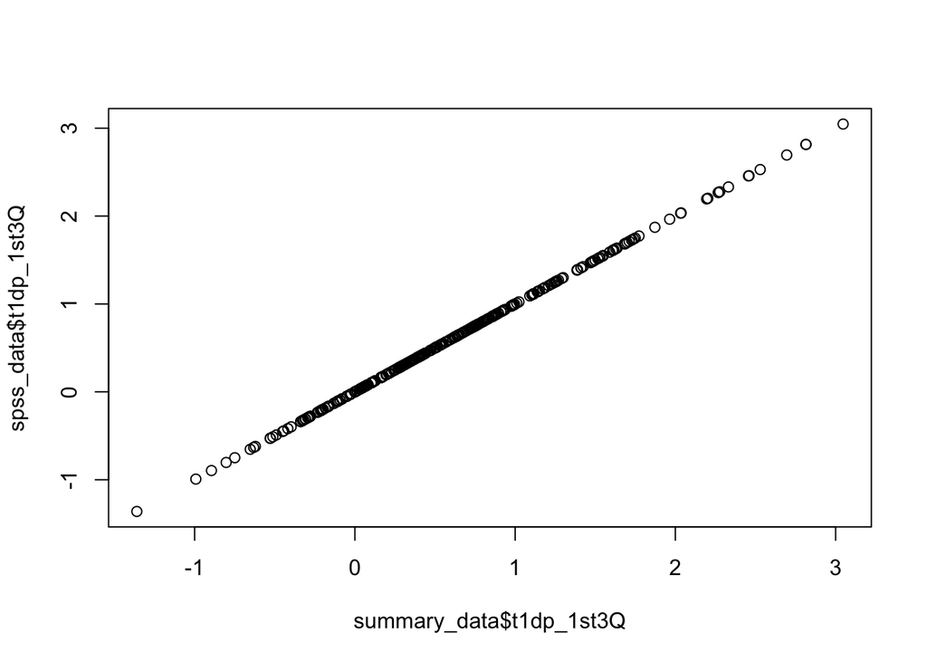

```r
compare_data <- summary_data %>%
  left_join(spss_data)

plot(summary_data$t1dp_1st3Q, spss_data$t1dp_1st3Q)
```

```r
# plot(summary_data$t2dp_1st3Q, spss_data$t2dp_1st3Q)
# # #
# plot(summary_data$t1dp_lastQ, spss_data$t1dp_lastQ)
# plot(summary_data$t2dp_lastQ, spss_data$t2dp_lastQ)
```